# COMPSCIX 415.2 Homework 6

Pankaj Mittal

July 11, 2018

My Github repository for my assignments can be found at this URL: https://github.com/pankajmit/compscix-415-2-assignments.git

```r
library(mdsr)
library(tidyverse)
library(ggplot2)
library(nycflights13)
library(forcats)
library(lubridate)
library(mosaicData)
```

## Exercise 1

### 1. Variables in this data set are - outcome (alive/dead), smoker (yes/no) and age

### 2. There are 1,314 observation. “outcome” represents whether the person is alive or dead after 20 years; “Smoker” represents smoking status at the baseline; “age” represents age at the time of first survey

### 3. Data is shown below but it does not convey an meaningful information, because age is missing

```r
Whickham %>% count(outcome, smoker)
```

```
## # A tibble: 4 x 3
##   outcome smoker     n
##   <fct>   <fct>  <int>
## 1 Alive   No       502
## 2 Alive   Yes      443
## 3 Dead    No       230
## 4 Dead    Yes      139
```

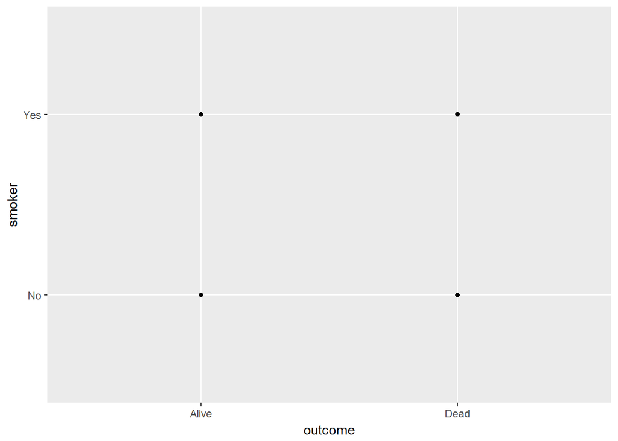

```r
ggplot(data = Whickham, mapping = aes(x = outcome, y = smoker)) +
  geom_point()
```

### 4. Results are not expected for the age group > 64. More people are dead who are non-smoker. This could be result of natural death of old age

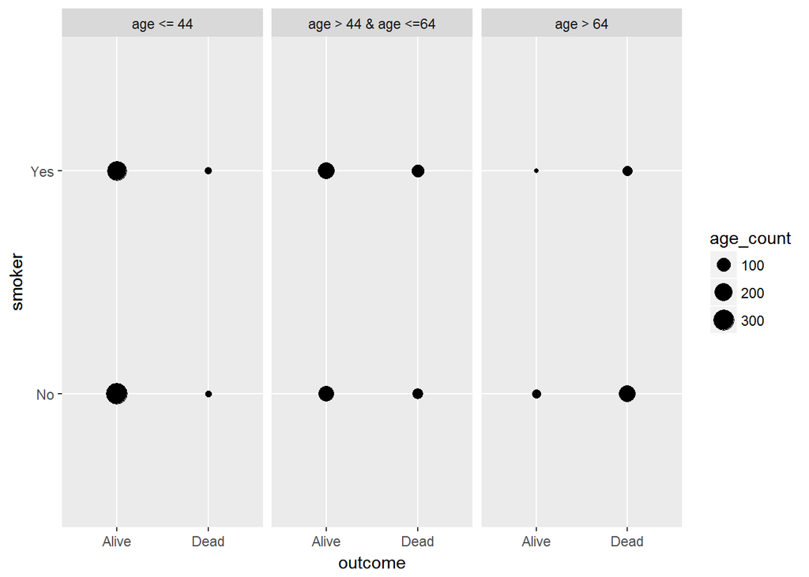

```r
Whickham_age_factor <- Whickham %>%
  mutate(age_factor = case_when(
                        age <= 44 ~ "age <= 44",
                        age > 44 & age <= 64 ~ "age > 44 & age <=64",
                        age > 64 ~"age > 64"))
Whickham_age_count <- Whickham_age_factor %>%
  group_by(outcome, smoker, age_factor) %>%
  summarize(age_count = n())

ggplot(data = Whickham_age_count, mapping = aes(x = outcome, y = smoker, size = age_count)) +
  geom_point() +
  facet_wrap(~age_factor)
```

## Exercise 2

### 1. Histogram and density curve of gamma distribution

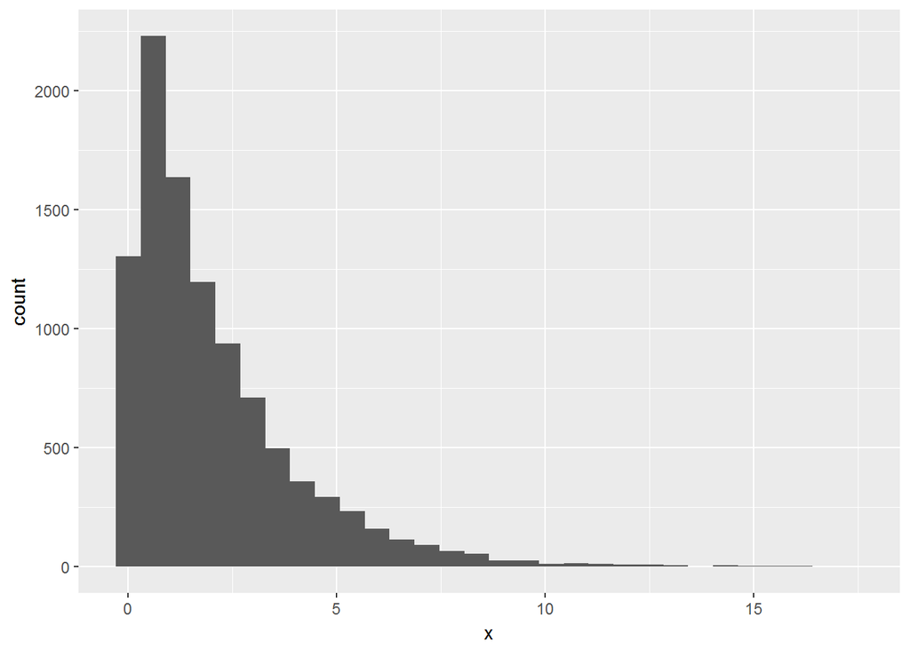

```r
n <- 10000
gamma_samp <- tibble(x = rgamma(n, shape = 1, scale = 2))
ggplot(data = gamma_samp, mapping = aes(x)) +
  geom_histogram()
```

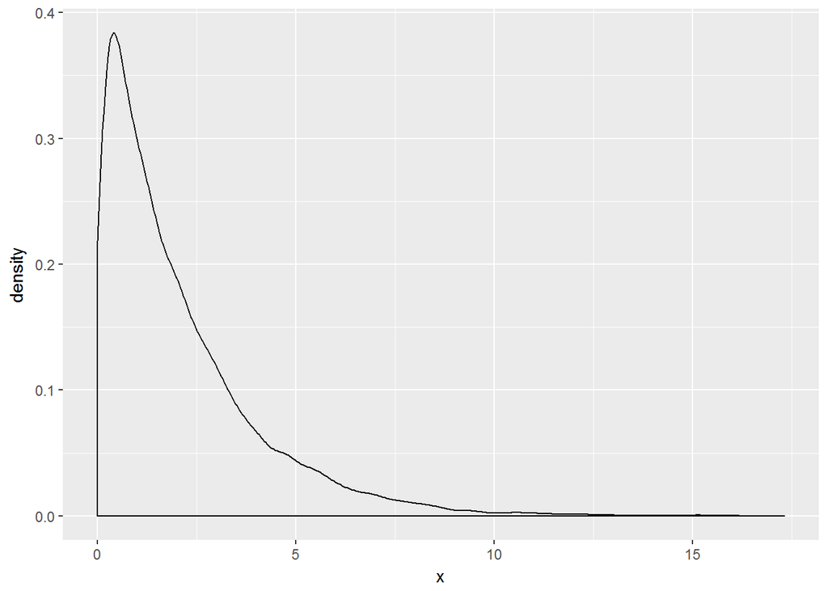

```r
ggplot(data = gamma_samp, mapping = aes(x)) +
  geom_density()
```

```r
mean(gamma_samp$x)
```

```
## [1] 2.042325
```

```r
sd(gamma_samp$x)
```

```
## [1] 2.014684
```

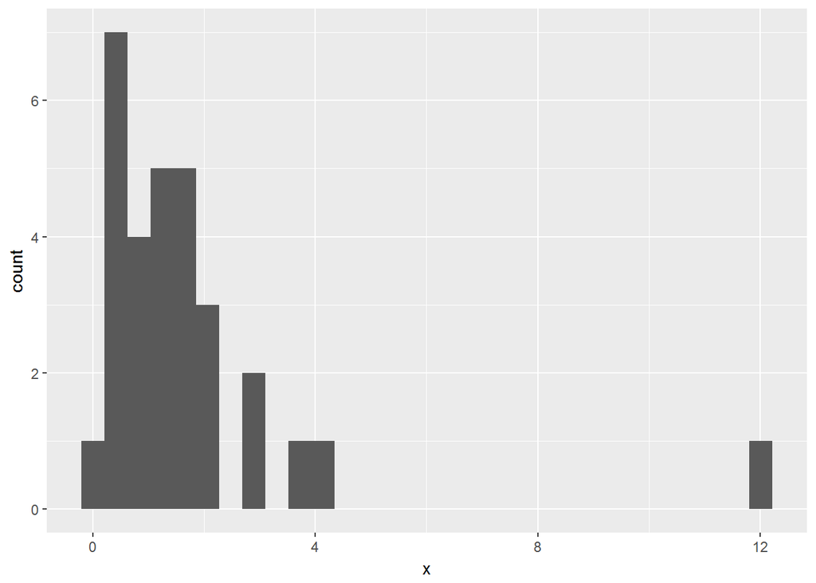

```r
n <- 30
gamma_samp <- tibble(x = rgamma(n, shape = 1, scale = 2))
ggplot(data = gamma_samp, mapping = aes(x)) +
  geom_histogram()
```

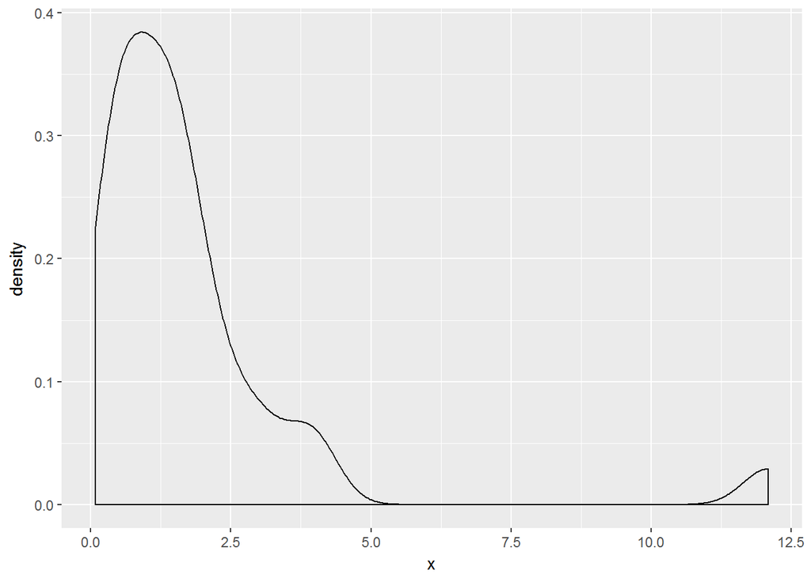

```r
ggplot(data = gamma_samp, mapping = aes(x)) +
  geom_density()
```

```r
mean(gamma_samp$x)
```

```
## [1] 1.763568
```

```r
sd(gamma_samp$x)
```

```
## [1] 2.201739
```

### 4. Build the vector of mean samples with 10000 entries

```r
mean_samp <- rep(NA, 10000)
for(i in 1:10000) {
  g_samp <- rgamma(30, shape = 1, scale = 2)
  mean_samp[i] <- mean(g_samp)
}

mean_samp <- tibble(mean_samp)
```

### 5. Build histogram of collection of means

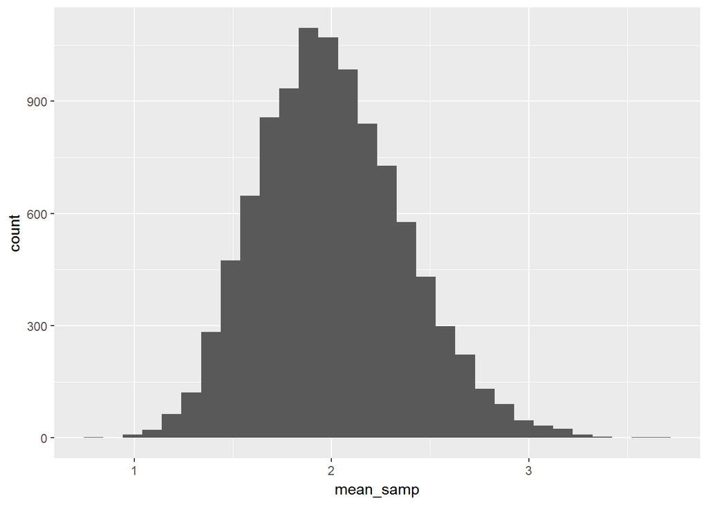

```r
ggplot(data = mean_samp, mapping = aes(mean_samp)) +
  geom_histogram()
```

```r
mean(mean_samp$mean_samp)
```

```
## [1] 2.003402
```

```r
sd(mean_samp$mean_samp)
```

```
## [1] 0.3704971
```

### 7. Any surprize - Standard deviation is very small compared to gamma distribution

### 8. Results are very close but this could be even closer if sample size was bit bigger

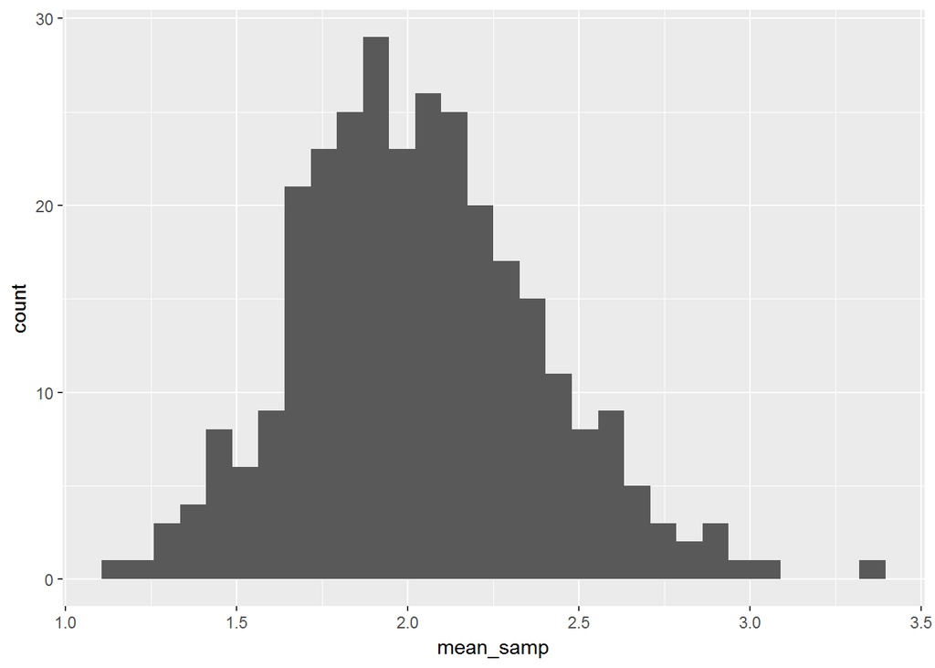

```r
mean_samp <- rep(NA, 300)
for(i in 1:300) {
  g_samp <- rgamma(30, shape = 1, scale = 2)
  mean_samp[i] <- mean(g_samp)
}

mean_samp <- tibble(mean_samp)

ggplot(data = mean_samp, mapping = aes(mean_samp)) +
  geom_histogram()
```

```r
mean(mean_samp$mean_samp)
```

```
## [1] 2.036522
```

```r
sd(mean_samp$mean_samp)
```

```
## [1] 0.352726
```

# COMPSCIX 415.2 Homework 6

Pankaj Mittal

July 11, 2018

My Github repository for my assignments can be found at this URL: https://github.com/pankajmit/compscix-415-2-assignments.git

```r
library(mdsr)
library(tidyverse)
library(ggplot2)
library(nycflights13)
library(forcats)
library(lubridate)
library(mosaicData)
```

## Exercise 1

### 1. Variables in this data set are - outcome (alive/dead), smoker (yes/no) and age

### 2. There are 1,314 observation. “outcome” represents whether the person is alive or dead after 20 years; “Smoker” represents smoking status at the baseline; “age” represents age at the time of first survey

### 3. Data is shown below but it does not convey an meaningful information, because age is missing

```r
Whickham %>% count(outcome, smoker)
```

```
## # A tibble: 4 x 3
##   outcome smoker     n
##   <fct>   <fct>  <int>
## 1 Alive   No       502
## 2 Alive   Yes      443
## 3 Dead    No       230
## 4 Dead    Yes      139
```

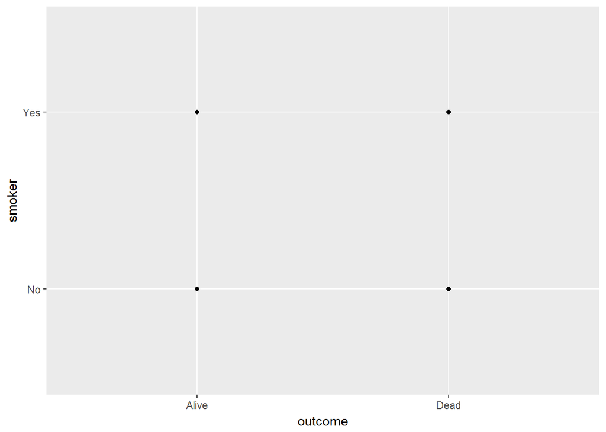

```r
ggplot(data = Whickham, mapping = aes(x = outcome, y = smoker)) +
  geom_point()
```

### 4. Results are not expected for the age group > 64. More people are dead who are non-smoker. This could be result of natural death of old age

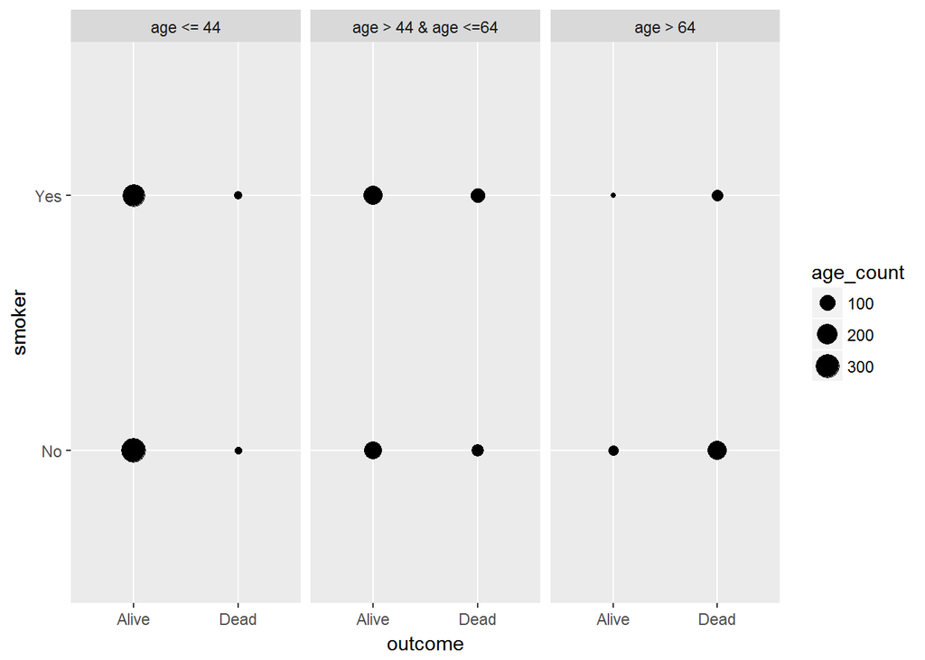

```r
Whickham_age_factor <- Whickham %>%
  mutate(age_factor = case_when(
                        age <= 44 ~ "age <= 44",
                        age > 44 & age <= 64 ~ "age > 44 & age <=64",
                        age > 64 ~"age > 64"))
Whickham_age_count <- Whickham_age_factor %>%
  group_by(outcome, smoker, age_factor) %>%
  summarize(age_count = n())

ggplot(data = Whickham_age_count, mapping = aes(x = outcome, y = smoker, size = age_count)) +
  geom_point() +
  facet_wrap(~age_factor)
```

## Exercise 2

### 1. Histogram and density curve of gamma distribution

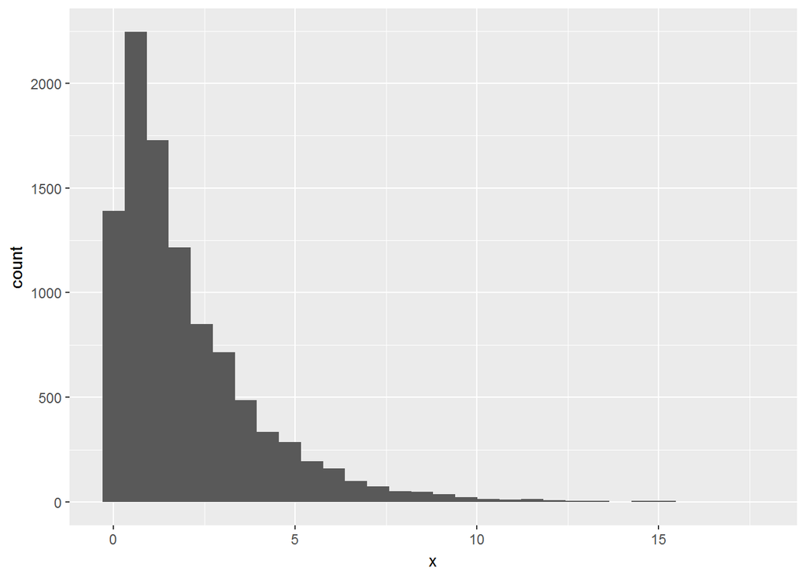

```r
n <- 10000
gamma_samp <- tibble(x = rgamma(n, shape = 1, scale = 2))
ggplot(data = gamma_samp, mapping = aes(x)) +
  geom_histogram()
```

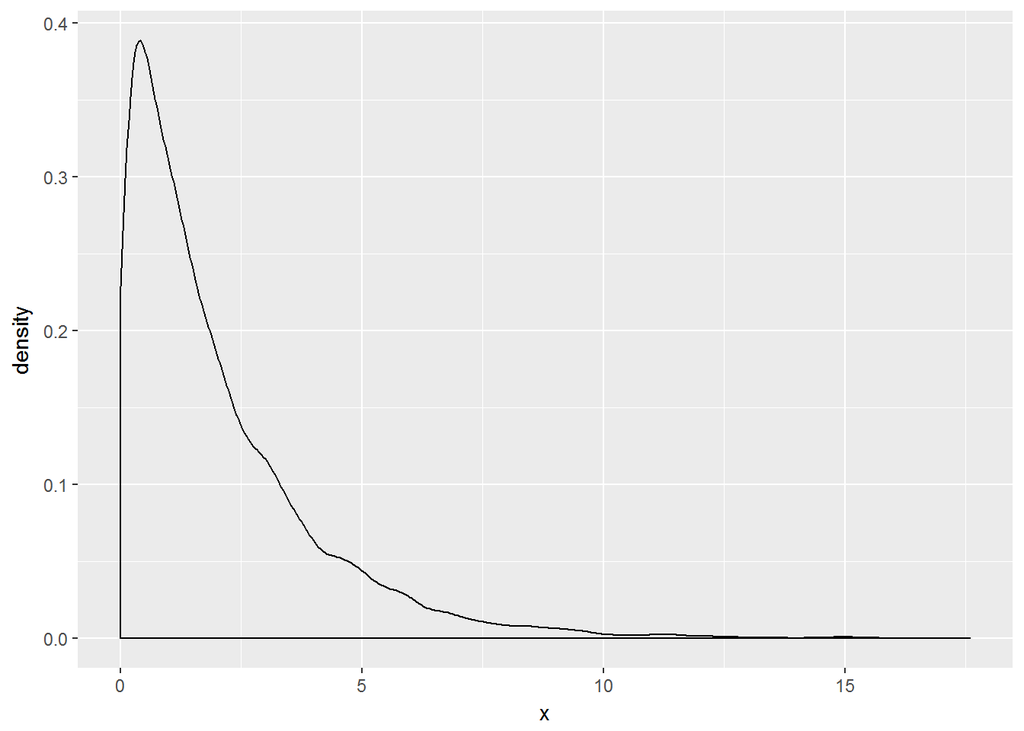

```r
ggplot(data = gamma_samp, mapping = aes(x)) +
  geom_density()
```

```r
mean(gamma_samp$x)
```

```
## [1] 1.995562
```

```r
sd(gamma_samp$x)
```

```
## [1] 1.99741
```

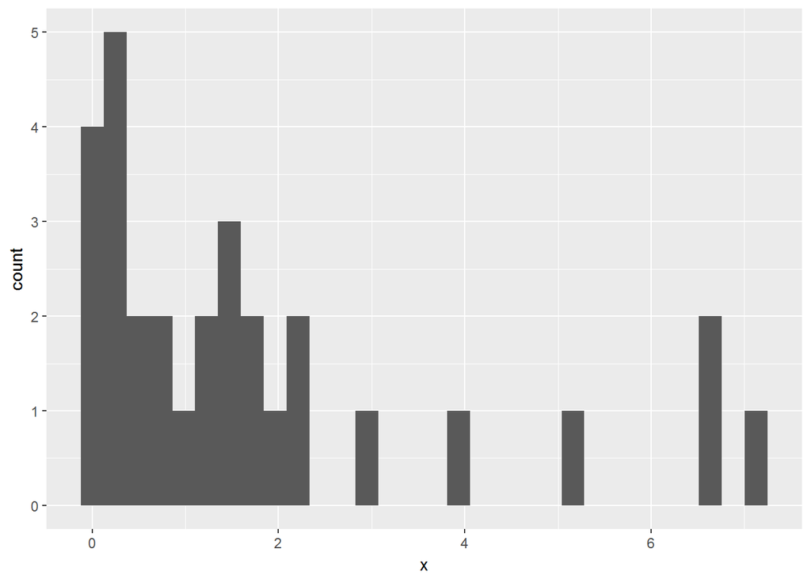

```r
n <- 30
gamma_samp <- tibble(x = rgamma(n, shape = 1, scale = 2))
ggplot(data = gamma_samp, mapping = aes(x)) +
  geom_histogram()
```

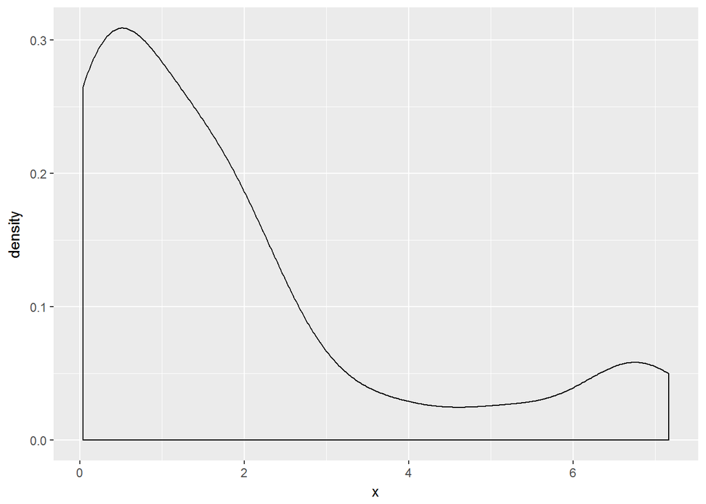

```r
ggplot(data = gamma_samp, mapping = aes(x)) +
  geom_density()
```

```r
mean(gamma_samp$x)
```

```
## [1] 1.78249
```

```r
sd(gamma_samp$x)
```

```
## [1] 2.07536
```

### 4. Build the vector of mean samples with 10000 entries

```r
mean_samp <- rep(NA, 10000)
for(i in 1:10000) {
  g_samp <- rgamma(30, shape = 1, scale = 2)
  mean_samp[i] <- mean(g_samp)
}

mean_samp <- tibble(mean_samp)
```

### 5. Build histogram of collection of means

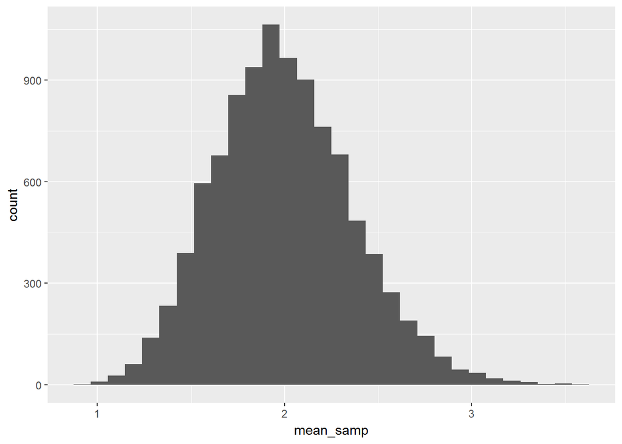

```r
ggplot(data = mean_samp, mapping = aes(mean_samp)) +
  geom_histogram()
```

```r
mean(mean_samp$mean_samp)
```

```
## [1] 1.996638
```

```r
sd(mean_samp$mean_samp)
```

```
## [1] 0.3678296
```

### 7. Any surprize - Standard deviation is very small compared to gamma distribution

### 8. Results are very close but this could be even close if sample size was bit bigger

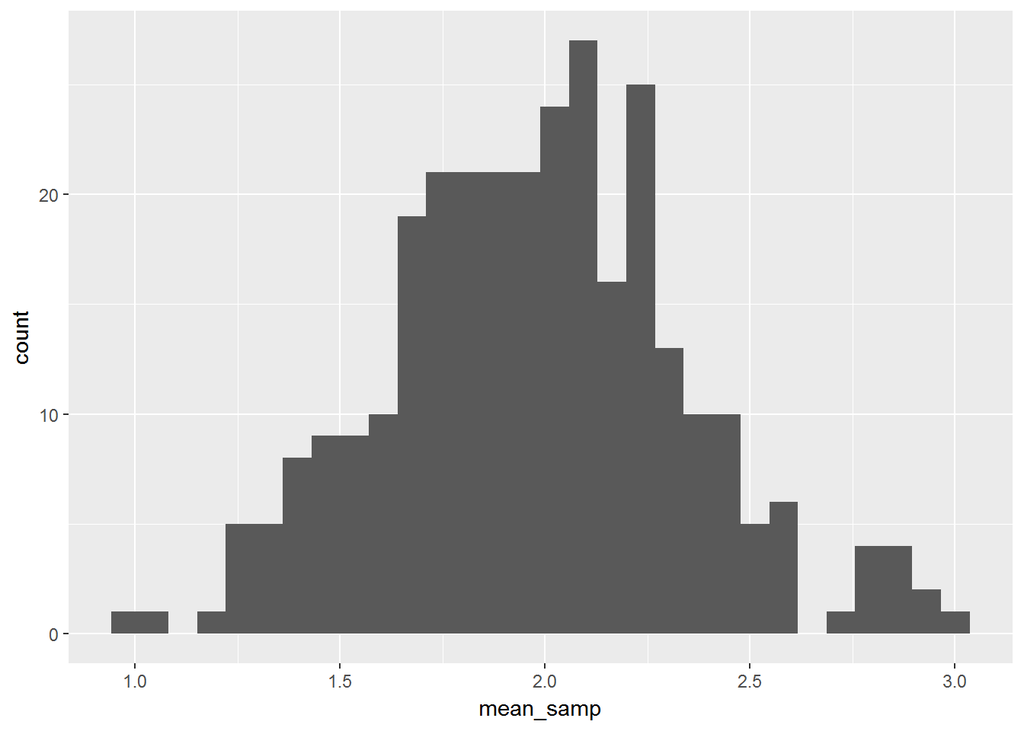

```r
mean_samp <- rep(NA, 300)
for(i in 1:300) {
  g_samp <- rgamma(30, shape = 1, scale = 2)
  mean_samp[i] <- mean(g_samp)
}

mean_samp <- tibble(mean_samp)

ggplot(data = mean_samp, mapping = aes(mean_samp)) +
  geom_histogram()
```

```r
mean(mean_samp$mean_samp)
```

```
## [1] 1.977462
```

```r
sd(mean_samp$mean_samp)
```

```
## [1] 0.3633692
```